# Introduction to matplotlib

```python
import warnings
warnings.filterwarnings('ignore')

import numpy as np
import pandas as pd
import matplotlib.pyplot as plt
import seaborn as sns
%matplotlib inline
```

```python
plt.rcParams['figure.figsize']=5,5
```

Below are the datasets we will use

```python
flights = sns.load_dataset('flights')
iris = sns.load_dataset('iris')
tips = sns.load_dataset('tips')
```

```python
flights.head()
```

|  | year | month | passengers |
| --- | --- | --- | --- |
| 0 | 1949 | Jan | 112 |
| 1 | 1949 | Feb | 118 |
| 2 | 1949 | Mar | 132 |
| 3 | 1949 | Apr | 129 |
| 4 | 1949 | May | 121 |

```python
flights.info()
```

```
<class 'pandas.core.frame.DataFrame'>
RangeIndex: 144 entries, 0 to 143
Data columns (total 3 columns):
 #   Column      Non-Null Count  Dtype
---  ------      --------------  -----
 0   year        144 non-null    int64
 1   month       144 non-null    category
 2   passengers  144 non-null    int64
dtypes: category(1), int64(2)
memory usage: 2.9 KB
```

Matplotlib is the cornerstone for data visualization in Python. E.g. seaborn relies on matplotlib behind the scenes

```
matplotlib.figure.Figure
```

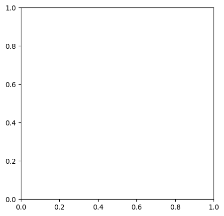

```python
fig, ax = plt.subplots()
type(fig)
```

### Line plots

```python
flights.groupby('month')['passengers'].mean()
```

```
month
Jan    241.750000
Feb    235.000000
Mar    270.166667
Apr    267.083333
May    271.833333
Jun    311.666667
Jul    351.333333
Aug    351.083333
Sep    302.416667
Oct    266.583333
Nov    232.833333
Dec    261.833333
Name: passengers, dtype: float64
```

```python
flights['month'].unique().astype('str')
```

```
array(['Jan', 'Feb', 'Mar', 'Apr', 'May', 'Jun', 'Jul', 'Aug', 'Sep',
       'Oct', 'Nov', 'Dec'], dtype='<U3')
```

```python
passengers_per_month = flights.groupby('month')['passengers'].mean().tolist()
months = flights['month'].unique().astype('str')
```

```python
months
```

```
array(['Jan', 'Feb', 'Mar', 'Apr', 'May', 'Jun', 'Jul', 'Aug', 'Sep',
       'Oct', 'Nov', 'Dec'], dtype='<U3')
```

```python
len(passengers_per_month)
```

[output not shown]

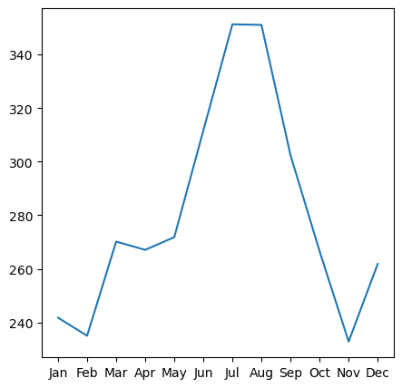

```python
fig, ax = plt.subplots()
ax.plot(months, passengers_per_month)
```

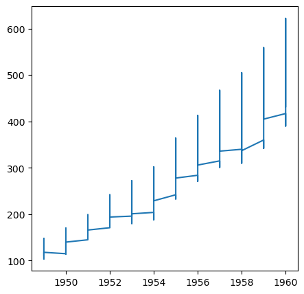

```python
fig, ax = plt.subplots()
ax.plot(flights['year'], flights['passengers'])
```

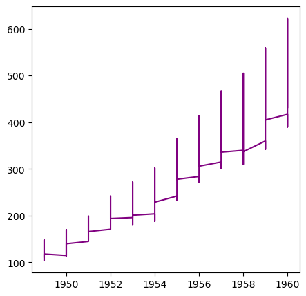

```python
fig, ax = plt.subplots()
ax.plot(flights['year'], flights['passengers'],color='purple')
```

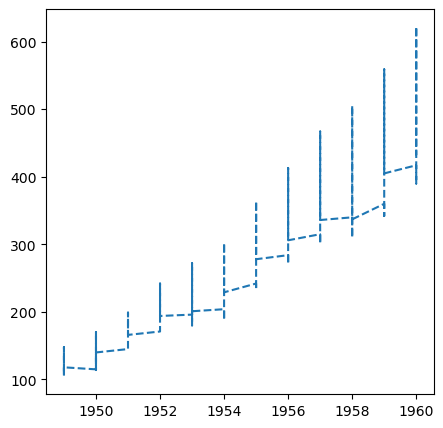

```python
fig, ax = plt.subplots()
ax.plot(flights['year'], flights['passengers'], linestyle='--')
```

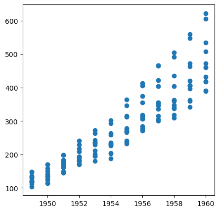

```python
fig, ax = plt.subplots()
ax.plot(flights['year'], flights['passengers'], marker='o', linestyle='None')
```

### Customizing labels

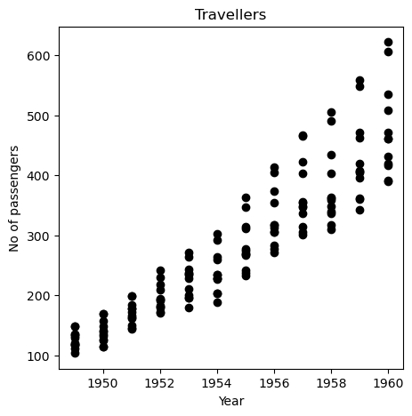

```python
fig, ax = plt.subplots()
ax.plot(flights['year'], flights['passengers'], marker='o', linestyle='None',color='black')
ax.set_xlabel('Year')
ax.set_ylabel('No of passengers')
ax.set_title('Travellers')
```

[output not shown]

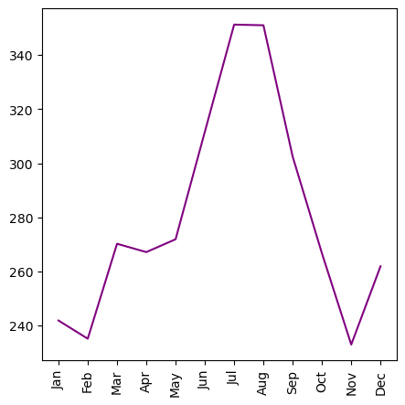

```python
fig, ax = plt.subplots()
ax.plot(months, passengers_per_month,color='purple')
ax.set_xticklabels(months,rotation=90)
```

### Including more data

```python
iris.head()
```

|  | sepal_length | sepal_width | petal_length | petal_width | species |
| --- | --- | --- | --- | --- | --- |
| 0 | 5.1 | 3.5 | 1.4 | 0.2 | setosa |
| 1 | 4.9 | 3.0 | 1.4 | 0.2 | setosa |
| 2 | 4.7 | 3.2 | 1.3 | 0.2 | setosa |
| 3 | 4.6 | 3.1 | 1.5 | 0.2 | setosa |
| 4 | 5.0 | 3.6 | 1.4 | 0.2 | setosa |

```python
iris['species'].unique()
```

```
array(['setosa', 'versicolor', 'virginica'], dtype=object)
```

```python
fig, ax = plt.subplots(2,2)
ax
```

[output not shown]

Let's add data now

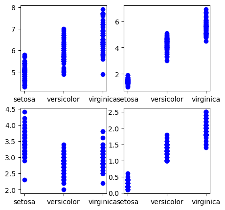

```python
fig, ax = plt.subplots(2,2)
ax[0,0].plot(iris['species'], iris['sepal_length'], marker='o', color='blue', linestyle='None')
ax[0,1].plot(iris['species'], iris['petal_length'], marker='o', color='blue', linestyle='None')
ax[1,0].plot(iris['species'], iris['sepal_width'], marker='o', color='blue', linestyle='None')
ax[1,1].plot(iris['species'], iris['petal_width'], marker='o', color='blue', linestyle='None')
```

Let's do some improvements

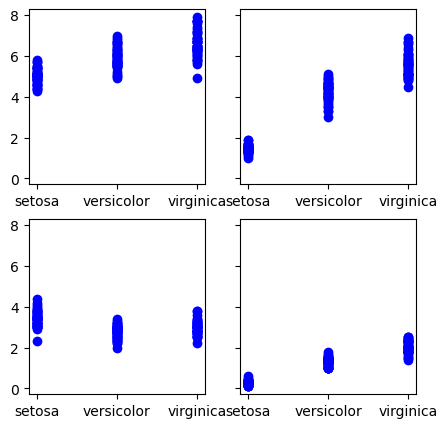

```python
fig, ax = plt.subplots(2,2, sharey=True)
ax[0,0].plot(iris['species'], iris['sepal_length'], marker='o', color='blue', linestyle='None')
ax[0,1].plot(iris['species'], iris['petal_length'], marker='o', color='blue', linestyle='None')
ax[1,0].plot(iris['species'], iris['sepal_width'], marker='o', color='blue', linestyle='None')
ax[1,1].plot(iris['species'], iris['petal_width'], marker='o', color='blue', linestyle='None')
```

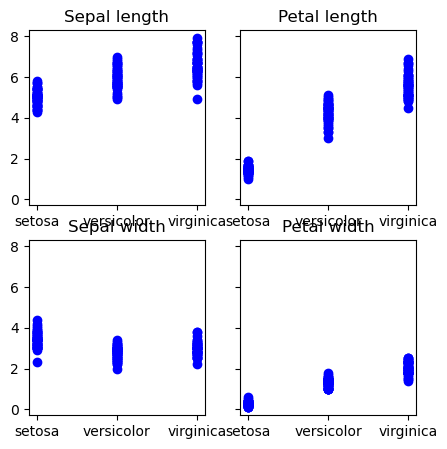

```python
fig, ax = plt.subplots(2,2, sharey=True)
ax[0,0].plot(iris['species'], iris['sepal_length'], marker='o', color='blue', linestyle='None')
ax[0,1].plot(iris['species'], iris['petal_length'], marker='o', color='blue', linestyle='None')
ax[1,0].plot(iris['species'], iris['sepal_width'], marker='o', color='blue', linestyle='None')
ax[1,1].plot(iris['species'], iris['petal_width'], marker='o', color='blue', linestyle='None')
ax[0,0].set_title('Sepal length')
ax[0,1].set_title('Petal length')
ax[1,0].set_title('Sepal width')
ax[1,1].set_title('Petal width')
```

### Bar charts

```python
tips.head()
```

|  | total_bill | tip | sex | smoker | day | time | size |
| --- | --- | --- | --- | --- | --- | --- | --- |
| 0 | 16.99 | 1.01 | Female | No | Sun | Dinner | 2 |
| 1 | 10.34 | 1.66 | Male | No | Sun | Dinner | 3 |
| 2 | 21.01 | 3.50 | Male | No | Sun | Dinner | 3 |
| 3 | 23.68 | 3.31 | Male | No | Sun | Dinner | 2 |
| 4 | 24.59 | 3.61 | Female | No | Sun | Dinner | 4 |

```python
tips_per_day = tips.groupby('day')['tip'].aggregate([np.mean,np.std])
tips_per_day
```

| day | mean | std |
| --- | --- | --- |
| Thur | 2.771452 | 1.240223 |
| Fri | 2.734737 | 1.019577 |
| Sat | 2.993103 | 1.631014 |
| Sun | 3.255132 | 1.234880 |

```
<BarContainer object of 4 artists>
```

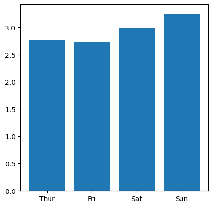

```python
fig, ax = plt.subplots()
ax.bar(tips_per_day.index, tips_per_day['mean'])
```

```
<BarContainer object of 4 artists>
```

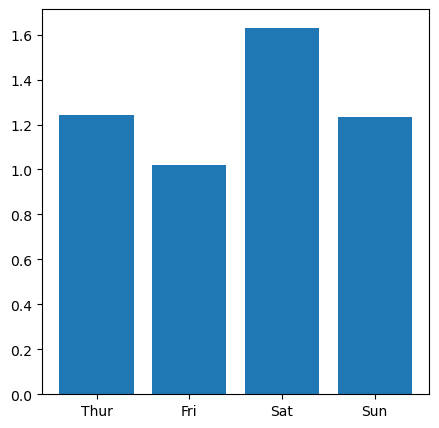

```python
fig, ax = plt.subplots()
ax.bar(tips_per_day.index, tips_per_day['std'])
#ax.set_xticklabels(tips_per_day.index, rotation=45)
```

It's common to include error bars

```
<BarContainer object of 4 artists>
```

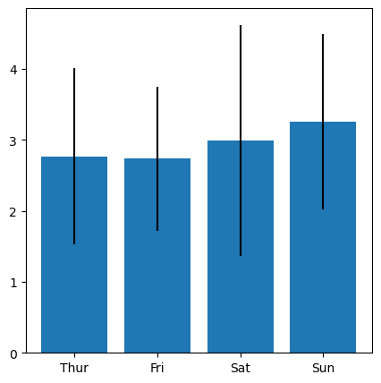

```python
fig, ax = plt.subplots()
ax.bar(tips_per_day.index, tips_per_day['mean'], yerr=tips_per_day['std'])
```

```python
bill_per_day = tips.groupby('day')[['tip', 'total_bill']].mean()
bill_per_day
```

| day | tip | total_bill |
| --- | --- | --- |
| Thur | 2.771452 | 17.682742 |
| Fri | 2.734737 | 17.151579 |
| Sat | 2.993103 | 20.441379 |
| Sun | 3.255132 | 21.410000 |

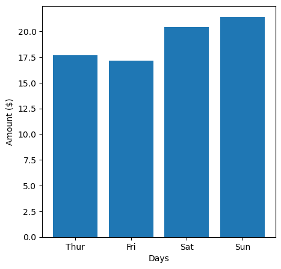

```python
fig, ax = plt.subplots()
ax.bar(bill_per_day.index, bill_per_day['total_bill'])
ax.set_xlabel('Days')
ax.set_ylabel('Amount ($)')
```

We can include both the total bil and the tip on the same figure

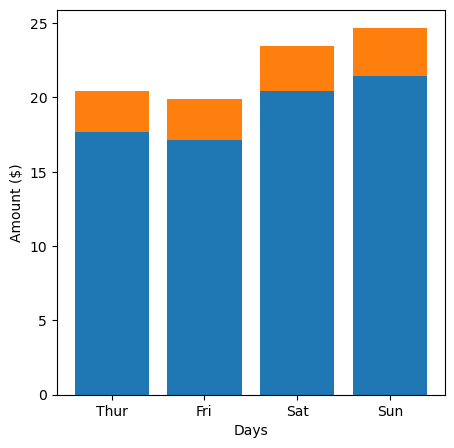

```python
fig, ax = plt.subplots()
ax.bar(bill_per_day.index, bill_per_day['total_bill'])
ax.bar(bill_per_day.index, bill_per_day['tip'], bottom=bill_per_day['total_bill'])
ax.set_xlabel('Days')
ax.set_ylabel('Amount ($)')
```

However, the above is incomplete withoug a legend. Let's do that

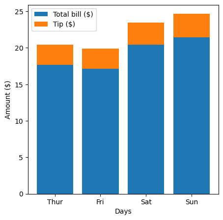

```python
fig, ax = plt.subplots()
ax.bar(bill_per_day.index, bill_per_day['total_bill'], label='Total bill ($)')
ax.bar(bill_per_day.index, bill_per_day['tip'], bottom=bill_per_day['total_bill'], label='Tip ($)')
ax.set_xlabel('Days')
ax.set_ylabel('Amount ($)')
ax.legend()
```

### Histograms

```python
iris.head()
```

|  | sepal_length | sepal_width | petal_length | petal_width | species |
| --- | --- | --- | --- | --- | --- |
| 0 | 5.1 | 3.5 | 1.4 | 0.2 | setosa |
| 1 | 4.9 | 3.0 | 1.4 | 0.2 | setosa |
| 2 | 4.7 | 3.2 | 1.3 | 0.2 | setosa |
| 3 | 4.6 | 3.1 | 1.5 | 0.2 | setosa |
| 4 | 5.0 | 3.6 | 1.4 | 0.2 | setosa |

```python
iris['species'].unique()
```

```
array(['setosa', 'versicolor', 'virginica'], dtype=object)
```

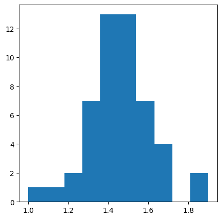

```python
fig, ax = plt.subplots()
ax.hist(iris[iris['species']=='setosa']['petal_length'])
```

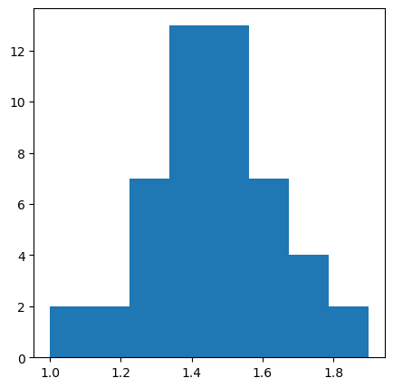

```python
fig, ax = plt.subplots()
ax.hist(iris[iris['species']=='setosa']['petal_length'],bins=8)
```

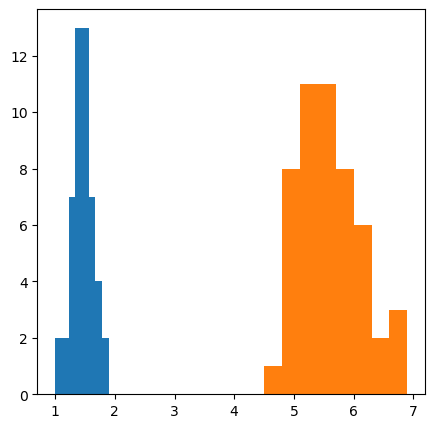

```python
fig, ax = plt.subplots()
ax.hist(iris[iris['species']=='setosa']['petal_length'],bins=8)
ax.hist(iris[iris['species']=='virginica']['petal_length'],bins=8)
```

We need to add labels

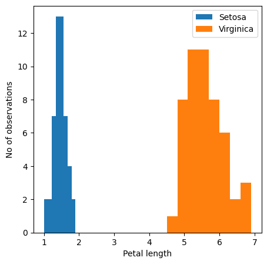

```python
fig, ax = plt.subplots()
ax.hist(iris[iris['species']=='setosa']['petal_length'],bins=8, label='Setosa')
ax.hist(iris[iris['species']=='virginica']['petal_length'],bins=8, label='Virginica')
ax.set_xlabel('Petal length')
ax.set_ylabel('No of observations')
ax.legend()
```

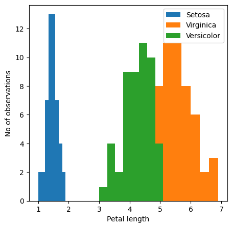

```python
fig, ax = plt.subplots()
ax.hist(iris[iris['species']=='setosa']['petal_length'],bins=8, label='Setosa')
ax.hist(iris[iris['species']=='virginica']['petal_length'],bins=8, label='Virginica')
ax.hist(iris[iris['species']=='versicolor']['petal_length'],bins=8, label='Versicolor')
ax.set_xlabel('Petal length')
ax.set_ylabel('No of observations')
ax.legend()
```

We can make them transparent in order to observe overlapping regions

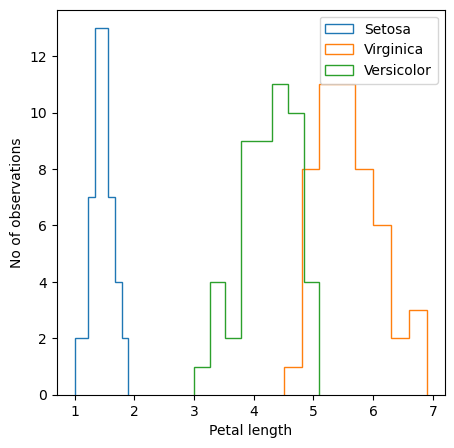

```python
fig, ax = plt.subplots()
ax.hist(iris[iris['species']=='setosa']['petal_length'],bins=8, label='Setosa', histtype='step')
ax.hist(iris[iris['species']=='virginica']['petal_length'],bins=8, label='Virginica', histtype='step')
ax.hist(iris[iris['species']=='versicolor']['petal_length'],bins=8, label='Versicolor', histtype='step')
ax.set_xlabel('Petal length')
ax.set_ylabel('No of observations')
ax.legend()
```

### Boxplots

```python
setosa_petal_length = iris[iris['species']=='setosa']['petal_length']
virginica_petal_length = iris[iris['species']=='virginica']['petal_length']
versicolor_petal_length = iris[iris['species']=='versicolor']['petal_length']
```

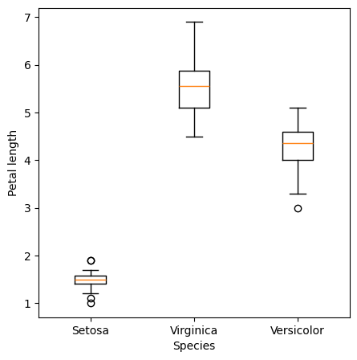

```python
fig, ax = plt.subplots()
ax.boxplot([setosa_petal_length, virginica_petal_length, versicolor_petal_length])
ax.set_xticklabels(['Setosa','Virginica', 'Versicolor'])
ax.set_xlabel('Species')
ax.set_ylabel('Petal length')
```

### Annotations

```python
tips.head()
```

|  | total_bill | tip | sex | smoker | day | time | size |
| --- | --- | --- | --- | --- | --- | --- | --- |
| 0 | 16.99 | 1.01 | Female | No | Sun | Dinner | 2 |
| 1 | 10.34 | 1.66 | Male | No | Sun | Dinner | 3 |
| 2 | 21.01 | 3.50 | Male | No | Sun | Dinner | 3 |
| 3 | 23.68 | 3.31 | Male | No | Sun | Dinner | 2 |
| 4 | 24.59 | 3.61 | Female | No | Sun | Dinner | 4 |

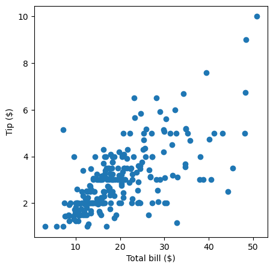

```python
fig, ax = plt.subplots()
ax.scatter(tips['total_bill'],tips['tip'])
ax.set_xlabel('Total bill ($)')
ax.set_ylabel('Tip ($)')
```

It's often useful to include annotation

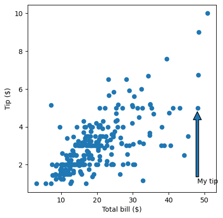

```python
fig, ax = plt.subplots()
ax.scatter(tips['total_bill'],tips['tip'])
ax.set_xlabel('Total bill ($)')
ax.set_ylabel('Tip ($)')

ax.annotate('My tip', xy=(48,4.8),
            xytext=(48,1),arrowprops={})
```

We can customize the arrow properties

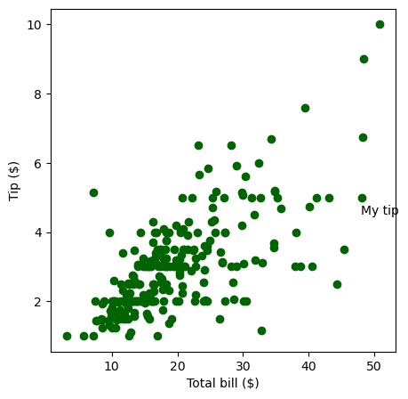

```python
fig, ax = plt.subplots()
ax.scatter(tips['total_bill'],tips['tip'],color='darkgreen')
ax.set_xlabel('Total bill ($)')
ax.set_ylabel('Tip ($)')

ax.annotate('My tip', xy=(48,4.5))
```

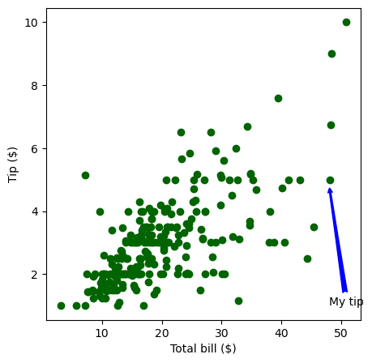

```python
fig, ax = plt.subplots()
ax.scatter(tips['total_bill'],tips['tip'],color='darkgreen')
ax.set_xlabel('Total bill ($)')
ax.set_ylabel('Tip ($)')

ax.annotate('My tip', xy=(48,4.8),
            xytext=(48,1),arrowprops={'color':'blue','arrowstyle':'fancy'})
```

We can include additional information. Let's check if we see any association with sex.

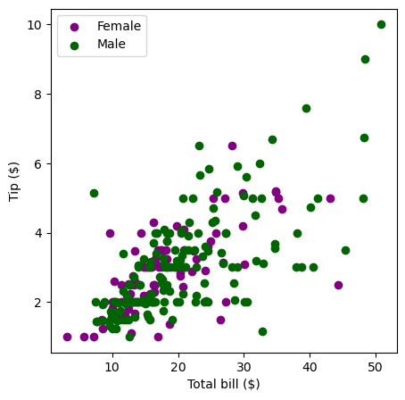

```python
fig, ax = plt.subplots()
ax.scatter(tips[tips['sex']=='Female']['total_bill'],
           tips[tips['sex']=='Female']['tip'],label='Female',color='purple')
ax.scatter(tips[tips['sex']=='Male']['total_bill'],
           tips[tips['sex']=='Male']['tip'],label='Male',color='darkgreen')
ax.set_xlabel('Total bill ($)')
ax.set_ylabel('Tip ($)')
ax.legend()
```

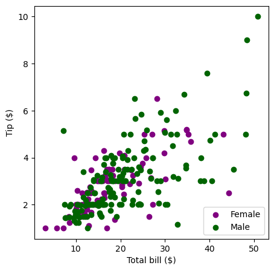

```python
fig, ax = plt.subplots()
ax.scatter(tips[tips['sex']=='Female']['total_bill'],
           tips[tips['sex']=='Female']['tip'],label='Female',color='purple')
ax.scatter(tips[tips['sex']=='Male']['total_bill'],
           tips[tips['sex']=='Male']['tip'],label='Male',color='darkgreen')
ax.set_xlabel('Total bill ($)')
ax.set_ylabel('Tip ($)')
ax.legend(loc='lower right')
```

## Heatmaps

```python
iris.head()
```

|  | sepal_length | sepal_width | petal_length | petal_width | species |
| --- | --- | --- | --- | --- | --- |
| 0 | 5.1 | 3.5 | 1.4 | 0.2 | setosa |
| 1 | 4.9 | 3.0 | 1.4 | 0.2 | setosa |
| 2 | 4.7 | 3.2 | 1.3 | 0.2 | setosa |
| 3 | 4.6 | 3.1 | 1.5 | 0.2 | setosa |
| 4 | 5.0 | 3.6 | 1.4 | 0.2 | setosa |

```python
iris.dtypes
```

```
sepal_length    float64
sepal_width     float64
petal_length    float64
petal_width     float64
species          object
dtype: object
```

```python
iris_corr = iris.loc[:,iris.columns != "species"].corr()
iris_corr
```

|  | sepal_length | sepal_width | petal_length | petal_width |
| --- | --- | --- | --- | --- |
| sepal_length | 1.000000 | -0.117570 | 0.871754 | 0.817941 |
| sepal_width | -0.117570 | 1.000000 | -0.428440 | -0.366126 |
| petal_length | 0.871754 | -0.428440 | 1.000000 | 0.962865 |
| petal_width | 0.817941 | -0.366126 | 0.962865 | 1.000000 |

[output not shown]

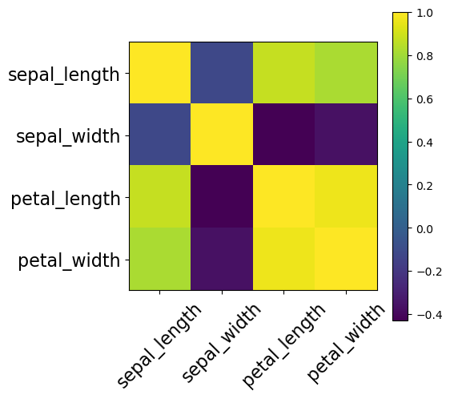

```python
fig, ax = plt.subplots()
iris_heatmap = ax.imshow(iris_corr)
plt.colorbar(iris_heatmap)
labels = ["sepal_length", "sepal_width", "petal_length", "petal_width"]
tick_marks = np.arange(len(labels))
plt.xticks(tick_marks, labels,fontsize=16, rotation=45)
plt.yticks(tick_marks, labels, fontsize=16)
```

```python
iris_heatmap?
```

[output not shown]

## Combinations of plot types

```python
iris.head()
```

|  | sepal_length | sepal_width | petal_length | petal_width | species |
| --- | --- | --- | --- | --- | --- |
| 0 | 5.1 | 3.5 | 1.4 | 0.2 | setosa |
| 1 | 4.9 | 3.0 | 1.4 | 0.2 | setosa |
| 2 | 4.7 | 3.2 | 1.3 | 0.2 | setosa |
| 3 | 4.6 | 3.1 | 1.5 | 0.2 | setosa |
| 4 | 5.0 | 3.6 | 1.4 | 0.2 | setosa |

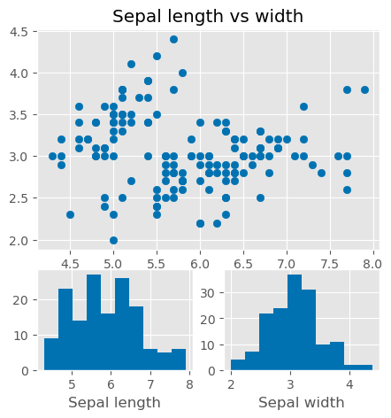

```python
gridsize = (3,2)
fig = plt.figure(figsize=(5,5))
ax1 = plt.subplot2grid(gridsize,(0,0), colspan=2, rowspan=2)
ax2 = plt.subplot2grid(gridsize, (2,0))
ax3 = plt.subplot2grid(gridsize, (2,1))

ax1.scatter(iris['sepal_length'], iris['sepal_width'])
ax1.set_title('Sepal length vs width')
ax2.hist(iris['sepal_length'])
ax2.set_xlabel('Sepal length')
ax3.hist(iris['sepal_width'])
ax3.set_xlabel('Sepal width')
```

## Plot styles

```python
plt.style.available
```

```
['Solarize_Light2',
 '_classic_test_patch',
 '_mpl-gallery',
 '_mpl-gallery-nogrid',
 'bmh',
 'classic',
 'dark_background',
 'fast',
 'fivethirtyeight',
 'ggplot',
 'grayscale',
 'seaborn-v0_8',
 'seaborn-v0_8-bright',
 'seaborn-v0_8-colorblind',
 'seaborn-v0_8-dark',
 'seaborn-v0_8-dark-palette',
 'seaborn-v0_8-darkgrid',
 'seaborn-v0_8-deep',
 'seaborn-v0_8-muted',
 'seaborn-v0_8-notebook',
 'seaborn-v0_8-paper',
 'seaborn-v0_8-pastel',
 'seaborn-v0_8-poster',
 'seaborn-v0_8-talk',
 'seaborn-v0_8-ticks',
 'seaborn-v0_8-white',
 'seaborn-v0_8-whitegrid',
 'tableau-colorblind10']
```

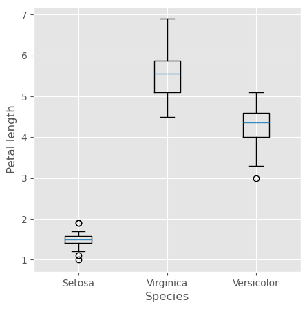

```python
plt.style.use('ggplot')
fig, ax = plt.subplots()
ax.boxplot([setosa_petal_length, virginica_petal_length, versicolor_petal_length])
ax.set_xticklabels(['Setosa','Virginica', 'Versicolor'])
ax.set_xlabel('Species')
ax.set_ylabel('Petal length')
```

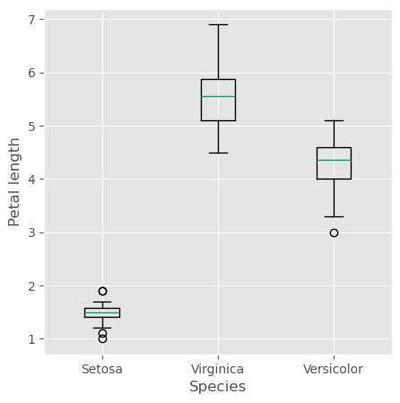

```python
plt.style.use('seaborn-v0_8-colorblind')
fig, ax = plt.subplots()
ax.boxplot([setosa_petal_length, virginica_petal_length, versicolor_petal_length])
ax.set_xticklabels(['Setosa','Virginica', 'Versicolor'])
ax.set_xlabel('Species')
ax.set_ylabel('Petal length')
```

Changing figure dimensions

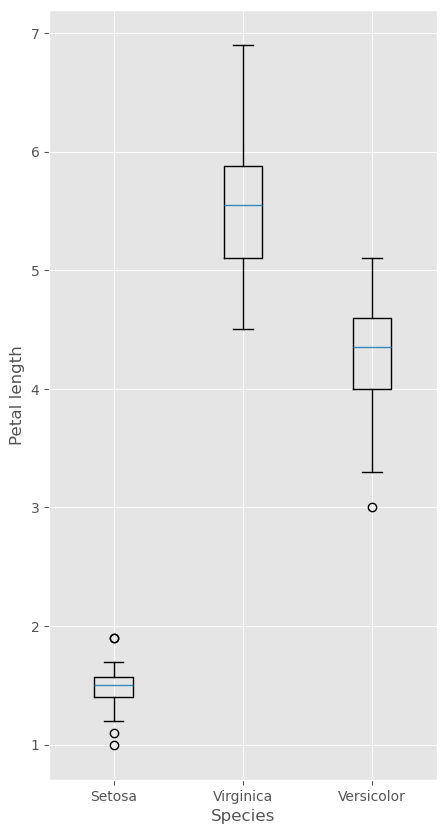

```python
plt.style.use('ggplot')
fig, ax = plt.subplots()
ax.boxplot([setosa_petal_length, virginica_petal_length, versicolor_petal_length])
ax.set_xticklabels(['Setosa','Virginica', 'Versicolor'])
ax.set_xlabel('Species')
ax.set_ylabel('Petal length')

fig.set_size_inches([5,10])
```

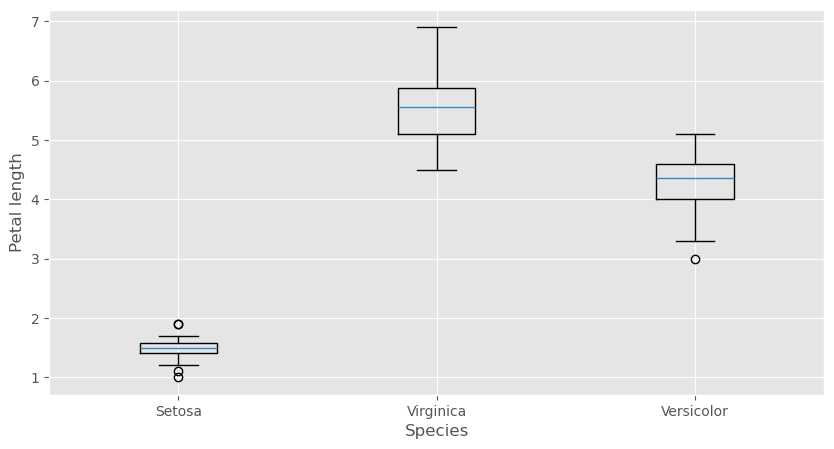

```python
plt.style.use('ggplot')
fig, ax = plt.subplots()
ax.boxplot([setosa_petal_length, virginica_petal_length, versicolor_petal_length])
ax.set_xticklabels(['Setosa','Virginica', 'Versicolor'])
ax.set_xlabel('Species')
ax.set_ylabel('Petal length')

fig.set_size_inches([10,5])
```

Saving a figure

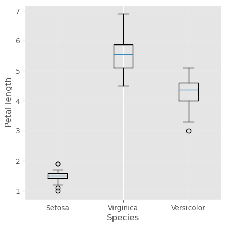

```python
plt.style.use('ggplot')
fig, ax = plt.subplots()
ax.boxplot([setosa_petal_length, virginica_petal_length, versicolor_petal_length])
ax.set_xticklabels(['Setosa','Virginica', 'Versicolor'])
ax.set_xlabel('Species')
ax.set_ylabel('Petal length')

fig.savefig('iris_boxplot.pdf')
fig.savefig('iris_boxplot.png', dpi=300)
```

In case we want to reduce whitespace area when saving to a file we can use the following

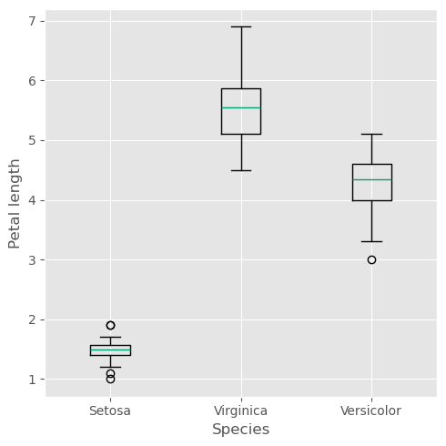

```python
plt.style.use('seaborn-v0_8-colorblind')
fig, ax = plt.subplots()
ax.boxplot([setosa_petal_length, virginica_petal_length, versicolor_petal_length])
ax.set_xticklabels(['Setosa','Virginica', 'Versicolor'])
ax.set_xlabel('Species')
ax.set_ylabel('Petal length')

fig.tight_layout()
fig.savefig('iris_boxplot_tight.pdf')
```

## Exercises

### Exercise 1

We will work with the `diamonds` dataset. The dataset is available through the `seaborn` package. You will have to run the following: `diamonds = sns.load_dataset('diamonds')`. For all the plots use a customed style of your choice.

- Create a scatter plot with the `carat` on the x axis and the `price` variable on the y axis. Label the axis appropriately.
- Create the same scatter plot as above, but this type use a different colour for each `cut` value. Label the axis appropriately and include a legend.
- Create a bar chart showing the price for the different colours. Add also standard error bars. Add also standard error bars. To calculate the standard error of the mean you can use the `scipy.stats.sem`.
- Create a stacked bar chart including the mean values of the `x`, `y` and `z` columns for each clarity value.
- Create a boxplot with the price range for the different `cut` values.
- Calculate the Pearson correlations amongst all numeric columns. Create a heatmap plot from the correlation matrix, including a colour bar showing the range of colours for the corresponding correlation values.

### Exercise 2

We will work with the `snp_variants.txt` dataset. For all the plots use a customed style of your choice.

- Create a horizontal bar chart with the number of SNP variants of each chromosome.
- Create separate line plots for each chromosome depicting the base composition of the `Reference` column along non-overlapping windows of 10,000,000 base pairs (you will need to estimate first the frequency of each base [A,G,C,T] for every ten million base pairs). Save the plot in a pdf format.
- In the case of the first chromosome include annotation text. In particular add to the plot the text `Position of interest` at a suitable location and point using an arrow to the location where the frequency of the G base starts declining.